# DSAF NYPD Shooting Project

Sam Lausten

2023-04-24

## Data sources and citation

We obtained the NYPD Shooting Incident Information from the official website of the United States government, DATA.GOV (https://catalog.data.gov/dataset). Our focus was on the “NYPD Shooting Incident Data (Historic)” file. To obtain population data for the NY boroughs, we utilized “NYC Open Data,” a platform that provides free access to public data published by various New York City agencies and partners (https://opendata.cityofnewyork.us/).

## Imported libraries and Versions

The code snippet provided is an example of R code, which includes library imports in order to use functions from the `tidyverse` and `ggplot2` packages. These packages are commonly used in data analysis and visualization tasks in R.

The `install_packages()` should also be run in the console before starting for the required packages if not done so already.

The `library()` function is used to load packages into the current R session. Once loaded, the functions provided by the packages can be called in subsequent code.

The `tidyverse` package is a collection of packages designed for data manipulation, exploration, and visualization. The `ggplot2` package is a popular package for creating graphics and data visualizations.

The specific versions of R and the packages used are provided for reproducibility purposes. This ensures that others can run the code on the same versions of the software and obtain the same results. In this case, the code was run on R version 4.3.0 (2023-04-21) – “Already Tomorrow” Copyright (C) 2023 The R Foundation for Statistical Computing. Platform: x86_64-apple-darwin20 (64-bit)

```r
library(tidyverse)
```

```r
library(ggplot2)
library(dplyr)
library(readxl)
library(leaflet)
library(htmlwidgets)
library(patchwork)
```

## Reading and cleaning Data from NYPD Shootings URL

In the case of the NYPD shootings dataset, cleaning the data involved identifying and fixing any errors, missing values, or inconsistencies in the dataset. For example, we needed to ensure that the date and time variables were in a consistent and usable format, that missing values were correctly identified and dealt with, and that any data entry errors were fixed. By doing this, we could be confident that the data we were working with was accurate and representative of the underlying phenomena, allowing us to draw more reliable and robust conclusions from our analysis. Overall, data cleaning is an essential and often time-consuming step in the data analysis process, but it is critical to ensuring that the insights we generate are accurate and trustworthy.

```r
#Read in NYPD Shooting CSV using URL
NYPD_shootings_df <- read.csv("https://data.cityofnewyork.us/api/views/833y-fsy8/rows.csv?accessType=DOWNLOAD")

#Check data structures of df
str(NYPD_shootings_df)
```

```
## 'data.frame':    25596 obs. of  19 variables:
##  $ INCIDENT_KEY           : int  236168668 231008085 230717903 237712309 224465521 228252164 226950018 237710987 224701998 225295736 ...
##  $ OCCUR_DATE             : chr  "11/11/2021" "07/16/2021" "07/11/2021" "12/11/2021" ...
##  $ OCCUR_TIME             : chr  "15:04:00" "22:05:00" "01:09:00" "13:42:00" ...
##  $ BORO                   : chr  "BROOKLYN" "BROOKLYN" "BROOKLYN" "BROOKLYN" ...
##  $ PRECINCT               : int  79 72 79 81 113 113 42 52 34 75 ...
##  $ JURISDICTION_CODE      : int  0 0 0 0 0 0 0 0 0 0 ...
##  $ LOCATION_DESC          : chr  "" "" "" "" ...
##  $ STATISTICAL_MURDER_FLAG: chr  "false" "false" "false" "false" ...
##  $ PERP_AGE_GROUP         : chr  "" "45-64" "<18" "" ...
##  $ PERP_SEX               : chr  "" "M" "M" "" ...
##  $ PERP_RACE              : chr  "" "ASIAN / PACIFIC ISLANDER" "BLACK" "" ...
##  $ VIC_AGE_GROUP          : chr  "18-24" "25-44" "25-44" "25-44" ...
##  $ VIC_SEX                : chr  "M" "M" "M" "M" ...
##  $ VIC_RACE               : chr  "BLACK" "ASIAN / PACIFIC ISLANDER" "BLACK" "BLACK" ...
##  $ X_COORD_CD             : num  996313 981845 996546 1001139 1050710 ...
##  $ Y_COORD_CD             : num  187499 171118 187436 192775 184826 ...
##  $ Latitude               : num  40.7 40.6 40.7 40.7 40.7 ...
##  $ Longitude              : num  -74 -74 -74 -73.9 -73.8 ...
##  $ Lon_Lat                : chr  "POINT (-73.95650899099996 40.68131820000008)" "POINT (-74.00866668999998 40.63636384100005)" "POINT (-73.95566903799994 40.68114495900005)" "POINT (-73.939095905 40.69579171600003)" ...
```

```r
##Let's change the data types to appropriate types and drop unneeded/NULL data

# Convert OCCUR_DATE to Date type
NYPD_shootings_df$OCCUR_DATE <- as.Date(NYPD_shootings_df$OCCUR_DATE, format = "%m/%d/%Y")

# Convert OCCUR_TIME to POSIXct type
NYPD_shootings_df$OCCUR_TIME <- as.POSIXct(NYPD_shootings_df$OCCUR_TIME, format = "%H:%M:%S")

# Convert BORO, LOCATION_DESC, STATISTICAL_MURDER_FLAG, PERP_AGE_GROUP, PERP_SEX, PERP_RACE, VIC_AGE_GROUP, VIC_SEX, VIC_RACE to factor type
NYPD_shootings_df$BORO <- as.factor(NYPD_shootings_df$BORO)
NYPD_shootings_df$LOCATION_DESC <- as.factor(NYPD_shootings_df$LOCATION_DESC)
NYPD_shootings_df$STATISTICAL_MURDER_FLAG <- as.factor(NYPD_shootings_df$STATISTICAL_MURDER_FLAG)
NYPD_shootings_df$PERP_AGE_GROUP <- as.factor(NYPD_shootings_df$PERP_AGE_GROUP)
NYPD_shootings_df$PERP_SEX <- as.factor(NYPD_shootings_df$PERP_SEX)
NYPD_shootings_df$PERP_RACE <- as.factor(NYPD_shootings_df$PERP_RACE)
NYPD_shootings_df$VIC_AGE_GROUP <- as.factor(NYPD_shootings_df$VIC_AGE_GROUP)
NYPD_shootings_df$VIC_SEX <- as.factor(NYPD_shootings_df$VIC_SEX)
NYPD_shootings_df$VIC_RACE <- as.factor(NYPD_shootings_df$VIC_RACE)

# add day of week column
NYPD_shootings_df <- NYPD_shootings_df %>%
  mutate(DAY_OF_WEEK = weekdays(as.Date(OCCUR_DATE, format = "%m/%d/%Y")))

# Remove unnecessary columns
NYPD_shootings_df <- subset(NYPD_shootings_df, select = -c(JURISDICTION_CODE))

# Check for missing data
summary(NYPD_shootings_df)
```

```
##   INCIDENT_KEY         OCCUR_DATE           OCCUR_TIME
##  Min.   :  9953245   Min.   :2006-01-01   Min.   :2023-04-26 00:00:00.00
##  1st Qu.: 61593633   1st Qu.:2009-05-10   1st Qu.:2023-04-26 03:23:00.00
##  Median : 86437258   Median :2012-08-26   Median :2023-04-26 15:10:00.00
##  Mean   :112382648   Mean   :2013-06-13   Mean   :2023-04-26 12:39:17.99
##  3rd Qu.:166660833   3rd Qu.:2017-07-01   3rd Qu.:2023-04-26 20:45:00.00
##  Max.   :238490103   Max.   :2021-12-31   Max.   :2023-04-26 23:59:00.00
##
##             BORO          PRECINCT                        LOCATION_DESC
##  BRONX        : 7402   Min.   :  1.00                            :14977
##  BROOKLYN     :10365   1st Qu.: 44.00   MULTI DWELL - PUBLIC HOUS: 4559
##  MANHATTAN    : 3265   Median : 69.00   MULTI DWELL - APT BUILD  : 2664
##  QUEENS       : 3828   Mean   : 65.87   PVT HOUSE                :  893
##  STATEN ISLAND:  736   3rd Qu.: 81.00   GROCERY/BODEGA           :  622
##                        Max.   :123.00   BAR/NIGHT CLUB           :  588
##                                         (Other)                  : 1293
##  STATISTICAL_MURDER_FLAG PERP_AGE_GROUP PERP_SEX           PERP_RACE
##  false:20668                    :9344    : 9310   BLACK         :10668
##  true : 4928             18-24  :5844   F:  371                 : 9310
##                          25-44  :5202   M:14416   WHITE HISPANIC: 2164
##                          UNKNOWN:3148   U: 1499   UNKNOWN       : 1836
##                          <18    :1463             BLACK HISPANIC: 1203
##                          45-64  : 535             WHITE         :  272
##                          (Other):  60             (Other)       :  143
##  VIC_AGE_GROUP   VIC_SEX                             VIC_RACE
##  <18    : 2681   F: 2403   AMERICAN INDIAN/ALASKAN NATIVE:    9
##  18-24  : 9604   M:23182   ASIAN / PACIFIC ISLANDER      :  354
##  25-44  :11386   U:   11   BLACK                         :18281
##  45-64  : 1698             BLACK HISPANIC                : 2485
##  65+    :  167             UNKNOWN                       :   65
##  UNKNOWN:   60             WHITE                         :  660
##                            WHITE HISPANIC                : 3742
##    X_COORD_CD        Y_COORD_CD        Latitude       Longitude
##  Min.   : 914928   Min.   :125757   Min.   :40.51   Min.   :-74.25
##  1st Qu.:1000011   1st Qu.:182782   1st Qu.:40.67   1st Qu.:-73.94
##  Median :1007715   Median :194038   Median :40.70   Median :-73.92
##  Mean   :1009455   Mean   :207894   Mean   :40.74   Mean   :-73.91
##  3rd Qu.:1016838   3rd Qu.:239429   3rd Qu.:40.82   3rd Qu.:-73.88
##  Max.   :1066815   Max.   :271128   Max.   :40.91   Max.   :-73.70
##
##    Lon_Lat          DAY_OF_WEEK
##  Length:25596       Length:25596
##  Class :character   Class :character
##  Mode  :character   Mode  :character
##
##
##
##
```

## Visualizations of NYPD Shooting Data

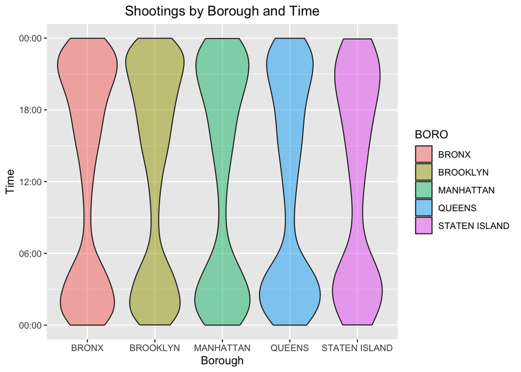

```r
# Convert OCCUR_TIME to POSIXct format for easier manipulation
NYPD_shootings_df$OCCUR_TIME <- as.POSIXct(NYPD_shootings_df$OCCUR_TIME, format = "%H:%M:%S")

ggplot(NYPD_shootings_df, aes(x=BORO, y=OCCUR_TIME)) +
  geom_violin(aes(fill=BORO), alpha=0.5) +
  scale_y_datetime(date_labels = "%H:%M") +
  labs(x="Borough", y="Time", title="Shootings by Borough and Time") +
  theme(plot.title = element_text(hjust = 0.5))
```

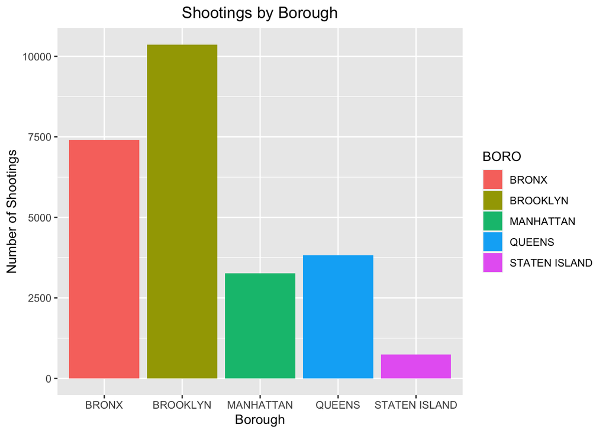

```r
# Count number of shootings in each borough
shootings_by_boro <- NYPD_shootings_df %>%
  group_by(BORO) %>%
  summarize(num_shootings = n()) %>%
  arrange(desc(num_shootings))

# Create bar chart of shootings by borough with vertical line
ggplot(shootings_by_boro, aes(x=BORO, y=num_shootings, fill=BORO)) +
  geom_bar(stat="identity") +
  labs(x="Borough", y="Number of Shootings", title="Shootings by Borough") +
  theme(plot.title = element_text(hjust = 0.5))
```

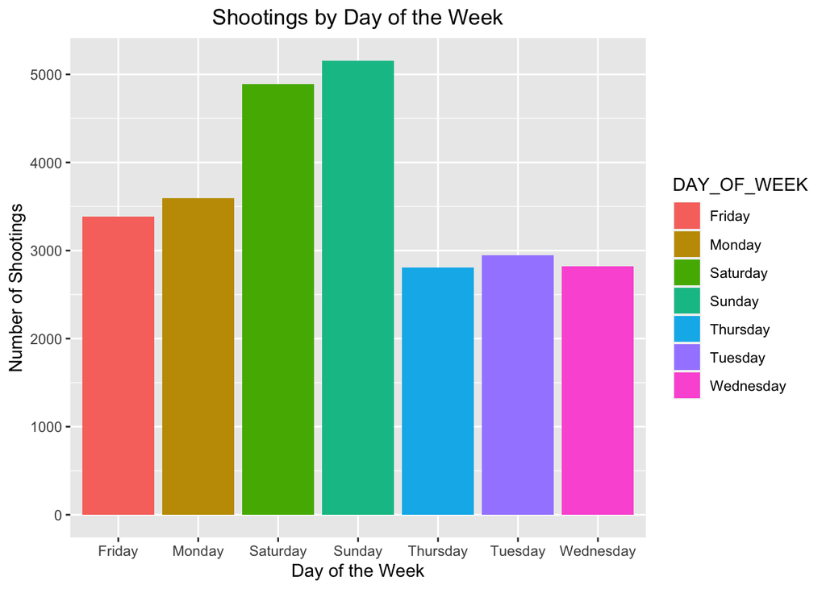

```r
# Let's see the distribution of shootings by race
race_counts <- table(NYPD_shootings_df$PERP_RACE)
race_counts_df <- data.frame(race = names(race_counts), count = as.numeric(race_counts))
race_counts_df$race <- factor(race_counts_df$race, levels = c("BLACK", "WHITE", "BLACK HISPANIC", "WHITE HISPANIC", "ASIAN / PACIFIC ISLANDER", "UNKNOWN", "OTHER"))

shootings_by_race <- ggplot(race_counts_df, aes(x = race, y = count, fill = race)) +
  geom_bar(stat = "identity") +
  theme_classic() +
  labs(title = "Number of NYPD Shootings by Race of Perpetrator", x = "Race", y = "Number of Shootings") +
  theme(axis.text.x = element_blank())


# Count number of shootings by day of the week
shootings_by_day <- NYPD_shootings_df %>%
  group_by(DAY_OF_WEEK) %>%
  summarize(num_shootings = n()) %>%
  arrange(desc(num_shootings))

# Create bar chart of shootings by day of the week
ggplot(shootings_by_day, aes(x=DAY_OF_WEEK, y=num_shootings, fill=DAY_OF_WEEK)) +
  geom_bar(stat="identity") +
  labs(x="Day of the Week", y="Number of Shootings", title="Shootings by Day of the Week") +
  theme(plot.title = element_text(hjust = 0.5))
```

[figure not shown]

```r
ggplot(NYPD_shootings_df, aes(x = as.numeric(str_remove_all(VIC_AGE_GROUP, "\\+")), fill = VIC_SEX)) +
  geom_density(alpha = 0.5) +
  scale_x_continuous(breaks = seq(0, 100, by = 10), limits = c(0, 100)) +
  labs(x = "Victim Age", y = "Density", title = "Age Distribution of Shooting Victims by Sex") +
  facet_wrap(vars(VIC_SEX)) +
  theme(plot.title = element_text(hjust = 0.5))
```

```r
# Create map object
map <- leaflet(data = NYPD_shootings_df) %>%
  addTiles() %>%
  setView(lng = -73.95, lat = 40.7, zoom = 11)

# Add markers layer
map <- map %>% addMarkers(
  lng = ~Longitude, lat = ~Latitude,
  clusterOptions = markerClusterOptions(),
  popup = ~paste("Date: ", OCCUR_DATE, "<br>",
                 "Time: ", OCCUR_TIME, "<br>",
                 "Borough: ", BORO, "<br>",
                 "Victim Age Group: ", VIC_AGE_GROUP, "<br>",
                 "Victim Sex: ", VIC_SEX, "<br>",
                 "Victim Race: ", VIC_RACE, "<br>")
)

saveWidget(map, "NYPD_shootings_map.html", selfcontained = TRUE)
```